# W07-Reflection Essay-Introduction to Positron

Author

Briana Maximino

Published

March 11, 2026

# Essay Prompts

## 1. **Download and Install Positron.**

### Video 1:

#library(dplyr)

df |> filter( score > 75 )

```
$data
# A tibble: 200 × 3
   student_id name       score
   <chr>      <chr>      <dbl>
 1 S001       Student_1     91
 2 S002       Student_2     68
 3 S003       Student_3     79
 4 S004       Student_4     83
 5 S005       Student_5     80
 6 S006       Student_6     74
 7 S007       Student_7     93
 8 S008       Student_8     74
 9 S009       Student_9     99
10 S010       Student_10    74
# ℹ 190 more rows

$plot
```

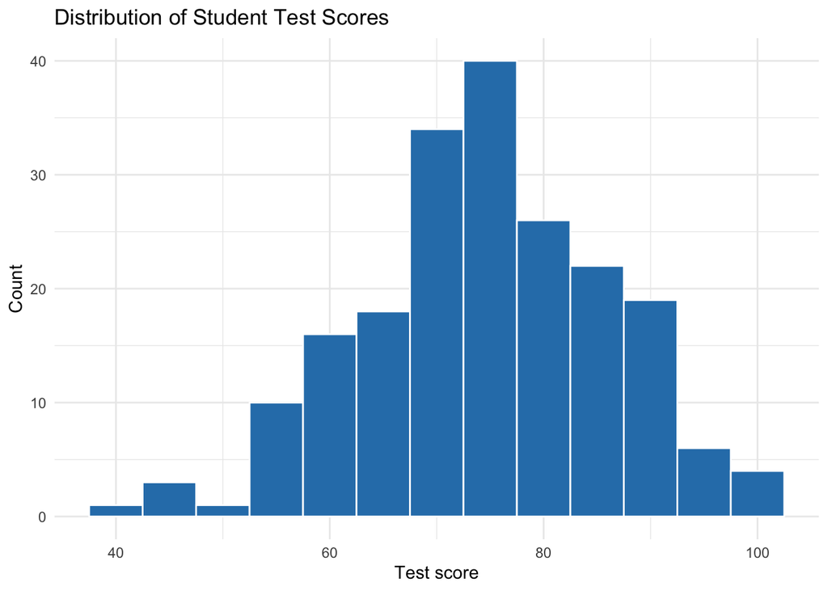

```r
library(tibble)
library(ggplot2)

set.seed(42)
n <- 200

df <- tibble(
  student_id = sprintf("S%03d", seq_len(n)),
  name = paste0("Student_", seq_len(n)),
  score = pmin(pmax(round(rnorm(n, mean = 75, sd = 12)), 0), 100)
)

p <- ggplot(df, aes(x = score)) +
  geom_histogram(binwidth = 5, color = "white", fill = "#2c7fb8") +
  labs(title = "Distribution of Student Test Scores", x = "Test score", y = "Count") +
  theme_minimal()

list(data = df, plot = p)
```

### Video Step 2:

```python
# python
from pathlib import Path
import polars as pl

path = Path("data/georgia-aquarium-species.csv")
species = pl.read_csv(path)

# If the file was parsed into one column whose name contains the two headers joined by a comma,
# split that column into separate columns and trim whitespace.
if len(species.columns) == 1 and "," in species.columns[0]:
    merged = species.columns[0]
    new_names = [n.strip() for n in merged.split(",")]
    split_exprs = [pl.col(merged).str.split(",").arr.get(i).alias(name) for i, name in enumerate(new_names)]
    species = species.with_columns(split_exprs).select(new_names)

species
```

shape: (10, 2)

| species str | conservation_status str |
| --- | --- |
| "Shark" | "Endangered" |
| "Sea Turtle" | "Vulnerable" |
| "Jellyfish" | "Least Concern" |
| "Clownfish" | "Least Concern" |
| "Dolphin" | "Near Threatened" |
| "Octopus" | "Data Deficient" |
| "Stingray" | "Vulnerable" |
| "Whale Shark" | "Endangered" |
| "Penguin" | "Near Threatened" |
| "Seal" | "Least Concern" |

```python
# python
from pathlib import Path
import polars as pl

path = Path("data/georgia-aquarium-species.csv")
species = pl.read_csv(path)

if len(species.columns) == 1 and "," in species.columns[0]:
    merged = species.columns[0]
    new_names = [n.strip() for n in merged.split(",")]

    # Try a Polars string-based split first
    try:
        split_exprs = [pl.col(merged).str.split(",").arr.get(i).alias(name) for i, name in enumerate(new_names)]
        species = species.with_columns(split_exprs).select(new_names)
    except Exception:
        # Fallback: use pandas to handle rows that are Python lists or other odd types
        df_pd = species.to_pandas()
        df_pd[merged] = df_pd[merged].apply(lambda v: ",".join(v) if isinstance(v, (list, tuple)) else v)
        new_df = df_pd[merged].str.split(",", expand=True)
        new_df.columns = new_names
        species = pl.from_pandas(new_df)

species
```

shape: (10, 2)

| species str | conservation_status str |
| --- | --- |
| "Shark" | "Endangered" |
| "Sea Turtle" | "Vulnerable" |
| "Jellyfish" | "Least Concern" |
| "Clownfish" | "Least Concern" |
| "Dolphin" | "Near Threatened" |
| "Octopus" | "Data Deficient" |
| "Stingray" | "Vulnerable" |
| "Whale Shark" | "Endangered" |
| "Penguin" | "Near Threatened" |
| "Seal" | "Least Concern" |

```python
# %% Load libraries and data
import math

import plotnine as p9
import polars as pl

species = pl.read_csv("./data/georgia-aquarium-species.csv")
species
```

shape: (10, 2)

| species str | conservation_status str |
| --- | --- |
| "Shark" | "Endangered" |
| "Sea Turtle" | "Vulnerable" |
| "Jellyfish" | "Least Concern" |
| "Clownfish" | "Least Concern" |
| "Dolphin" | "Near Threatened" |
| "Octopus" | "Data Deficient" |
| "Stingray" | "Vulnerable" |
| "Whale Shark" | "Endangered" |
| "Penguin" | "Near Threatened" |
| "Seal" | "Least Concern" |

```python
# %% Summarize the number of species by conservation status

# Create an order for the categorical data
conservation_status_enum = pl.Enum(
    [
        # Conservation categories from most to least threatened
        "Critically Endangered",
        "Endangered",
        "Vulnerable",
        "Near Threatened",
        "Least Concern",
        "Data Deficient",
        "Not Evaluated",
    ]
)

# Create summary table
conservation_status_summary = (
    species
    .with_columns(
        pl.col("conservation_status").cast(conservation_status_enum)
    )
    .group_by("conservation_status")
    .len()
    .sort("conservation_status", descending=True)
)

conservation_status_summary
```

shape: (5, 2)

| conservation_status enum | len u32 |
| --- | --- |
| "Data Deficient" | 1 |
| "Least Concern" | 3 |
| "Near Threatened" | 2 |
| "Vulnerable" | 2 |
| "Endangered" | 2 |

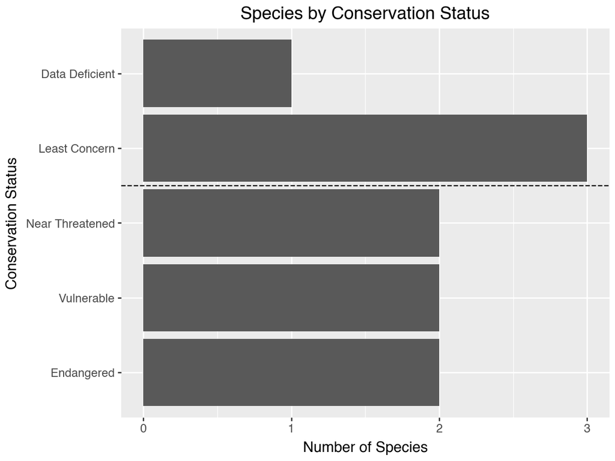

```python
# %% Plot the summary using Plotnine

threatened_index = 3.5  # Everything before this index is "threatened"

plot = (
    p9.ggplot(conservation_status_summary,
              p9.aes(x="conservation_status", y="len"))
    + p9.geom_col()
    + p9.coord_flip()
    + p9.geom_vline(xintercept=threatened_index, linetype="dashed")
    + p9.labs(
        title="Species by Conservation Status",
        x="Conservation Status",
        y="Number of Species"
    )
)

plot
```

## 2. **What do you like about Positron compared with RStudio?**

Based on the videos and activities, I like that Positron offers more help, such as the chatbot and the code suggestions. I also like that it has a more modern interface and is more user-friendly. I also like that it is open source and free to use. I also like that it has a /fix command that can help you fix errors in your code. I also like that it has a /explain command that can help you understand what your code is doing. I also like that it has a /suggest command that can help you improve your code. Overall, I think positron is a great tool for data analysis, and I am excited to use it in the future.

## 3. **In Video 4, the video demonstrates how you can use AI.**

### Describe the various ways you can use AI inside Positron. Some are free while others are not.

There are several ways to use AI inside Positron. Some of the free features include the chatbot, which can help you with coding questions and provide suggestions. The /fix command can help you fix errors in your code, and the /explain command can help you understand what your code is doing. The /suggest command can help you improve your code by providing suggestions for better practices or more efficient code.

### Which AI tools have you installed or set up? Which AI tools did you find beneficial for you?

I have set up the chatbot and the /fix command. I found the chatbot to be very helpful for getting quick answers to coding questions and for getting suggestions on how to improve my code. The /fix command is also very helpful for quickly resolving errors in my code without having to spend a lot of time trying to figure it out on my own. Overall, I think these AI tools can be very beneficial for improving productivity and learning new coding techniques.

## 4. **GitHub Copilot.**

### Apply for it and take a screenshot showing you were accepted into the education program.

[figure not shown]

Verified student status

### Play with it and do you find it helpful or distracting? Please elaborate

When using Github Copilot, I found it to be both helpful and distracting at times. It can be helpful in providing code suggestions and completing code snippets, which can speed up the coding process. However, it can also be distracting when it suggests code that is not relevant to what I am trying to do or when it interrupts my thought process with suggestions that I do not need. Overall, I think GitHub Copilot can be a useful tool for coding, but it is important to use it when needed and make sure to review the suggestions it provides to ensure they are appropriate for the task at hand.